# ADRECMO

Jolie Bruno, Antoine Kimmoun, Kevin Duarte, Feriel Azibani, Benjamin Deniaun

2026-01-20

# METHOD

This study is a monocentric, prospective, observational investigation conducted in Nancy Hospital between 10.10.2017 and 24.05.2022, enrolling 50 adult patients with refractory cardiogenic shock requiring veno-arterial extracorporeal membrane oxygenation (VA-ECMO) support (NCT03327493).

The study was carried out in accordance with the Declaration of Helsinki and approved by the local institutional ethics committee. Written informed consent was obtained from all patients or their legal representatives prior to inclusion.

## Patient Population

Cardiogenic shock was defined as a systolic blood pressure (SBP) <90 mmHg or a mean arterial pressure (MAP) <65 mmHg despite adequate volume resuscitation, accompanied by signs of peripheral hypoperfusion (e.g., cold extremities, oliguria, altered mental status) and a cardiac index <2.2 L/min/m². Refractoriness was defined as a hyporesponsiveness to norepinephrine and/or the persistence of profound clinical signs of hypoperfusion despite optimal resuscitation efforts. Eligible patients were adults (≥18 years old) affiliated with a health insurance system. Cardiogenic shock etiologies included acute ischemic coronary artery disease, primary or ischemic-related dilated cardiomyopathy, myocarditis and stress-induced cardiomyopathy. Patients were excluded if cardiogenic shock was secondary to cardiotoxic poisoning, if they were pregnant, or were under legal protective supervision (e.g., court-appointed guardianship).

## ECMO Weaning Protocol

A standardized weaning protocol was applied to all patients prior to ECMO explantation. At a constant mean arterial pressure (MAP) between 65 and 75 mmHg, cardiac output was assessed by transthoracic echocardiography at two predefined timepoints: 1. Baseline under full support (ECLS flow at 3.0 L/min) and 2. Low-flow test after 45 minutes of reduced ECMO flow (1.5 L/min). Measurements included velocity time integral (VTI) at the left ventricular outflow tract and left ventricular ejection fraction. Changes in norepinephrine and dobutamin dosage during this period were also documented. The decision to explant ECMO was based on clinical tolerance, hemodynamic stability and echocardiographic parameters during the weaning trial.

## Statistical Analysis

To explore the distribution of ADRB1 and ADRB2 expression over time in relation to clinical outcomes, boxplots were generated at three timepoints (implantation, day 3–5, and explantation). To evaluate the temporal dynamics of ADRB1 and ADRB2 expression across clinical outcomes, we used linear mixed-effects models with time, outcome group (ECMO weaning, bridge to LVAD/transplant, or death), and their interaction as fixed effects. Random intercepts and slopes for time were included to account for intra-patient variability. When appropriate, receptor expression values were log10-transformed. Interaction terms were tested using likelihood ratio tests between full and reduced models, and Type III ANOVA with Kenward-Roger approximation was used for fixed effects.

# Timepoint check of the blood sample at day 0

```r
summary_stats <- df %>%
  mutate(time_diff_hours = time_diff_mins / 60) %>%
  summarise(
    mean_hours = mean(time_diff_hours),
    sd_hours = sd(time_diff_hours),
    min = min(time_diff_hours),
    max = max(time_diff_hours)
  )
```

# TABLE 1: Characteristics of the population

```r
table1
```

Table 1: Characteristics of the population before ECMO implantation

| Variables | Missing | Overall |
| --- | --- | --- |
| n |  | 47 |
| Demographics |  |  |
| Age (years) | 0 | 59.0 [51.0, 66.0] |
| Gender = Female (%) | 0 | 7 (14.9) |
| Body Mass Index (kg/m²) | 3 | 26.5 [23.6, 29.5] |
| Medical History |  |  |
| Hypertension (%) | 0 | 18 (38.3) |
| Diabetes Mellitus (%) | 0 | 9 (19.1) |
| Heart Failure (%) | 0 | 16 (34.0) |
| Chronic Kidney Disease (%) | 0 | 5 (10.6) |
| Chronic Respiratory Disease (%) | 0 | 3 ( 6.4) |
| Neurological Deficit (%) | 0 | 4 ( 8.5) |
| Immunosuppression (%) | 0 | 4 ( 8.5) |
| Prior-adrenergic medications |  |  |
| Beta-blocker (%) | 0 | 22 (46.8) |
| Alpha-blocker (%) | 0 | 3 ( 6.4) |
| Cardiogenic shock cause |  |  |
| Non-ischemic (%) | 0 | 16 (34.0) |
| Ischemic (%) | 0 | 31 (66.0) |
| Cardiac Arrest Before Cannulation (%) | 0 | 25 (53.2) |
| Pre-ECMO Clinical parameters |  |  |
| Systolic Blood Pressure (mmHg) | 0 | 97.0 [86.5, 109.5] |
| Diastolic Blood Pressure (mmHg) | 0 | 63.0 [57.5, 72.0] |
| Mean Arterial Pressure (mmHg) | 0 | 73.0 [68.0, 81.0] |
| Heart Rate (bpm) | 0 | 96.0 [86.0, 117.0] |
| Pre-ECMO heart function |  |  |
| Pre-ECMO Ejection Fraction (%) | 4 | 20.0 [15.0, 22.5] |
| Pre-ECMO Aortic Velocity Time Integral (cm) | 8 | 7.0 [5.7, 8.5] |
| Pre-ECMO supports |  |  |
| Mechanical ventilation (%) | 0 | 34 (72.3) |
| Norepinephrine cumulative Dose on first day (γ/kg/24H) | 2 | 325.7 [20.0, 843.1] |
| Dobutamine cumulative Dose on first day (γ/kg/24H) | 2 | 3137.8 [0.0, 6000.0] |
| Pre-ECMO Biological assessment |  |  |
| Lactate (mmol/L) | 0 | 2.7 [1.7, 4.7] |
| Creatinine (µmol/L) | 0 | 149.0 [98.0, 204.0] |
| AST (IU/L) | 0 | 643.0 [144.0, 1188.5] |
| Bilirubin (mg/dL) | 1 | 21.0 [12.0, 39.5] |
| High Sensitivity Troponin I (ng/L) | 13 | 34363.5 [383.2, 186316.0] |
| NT-proBNP (pg/mL) | 24 | 10882.0 [2248.0, 26995.0] |
| Platelet Count (10⁹/L) | 0 | 178.0 [122.5, 273.5] |

Data are expressed in n(%) for categorical variables and median [25th–75th] for continuous variables.

```r
save_as_docx(table1, path = "Tables/Table1_characteristics.docx")
```

# TABLE 2: Management and Outcomes

```r
table2
```

Table 2: Outcomes

| Variables | Overall |
| --- | --- |
| n | 47 |
| ECMO Weaning (%) | 21 (44.7) |
| ECMO Duration (days) | 6.0 [3.0, 9.5] |
| ECMO Duration in weaned (days) | 5.0 [3.0, 8.0] |
| ECMO Duration in deceased (days) | 5.5 [3.0, 8.2] |
| Intra-Aortic Balloon Pump (%) | 27 (57.4) |
| Renal Replacement Therapy (%) | 13 (27.7) |
| Duration of Renal Replacement Therapy (days) | 0.0 [0.0, 5.0] |
| Duration of Mechanical Ventilation (days) | 5.0 [2.0, 9.5] |
| ICU Length of Stay (days) | 14.0 [6.0, 19.5] |
| Outcome |  |
| Death in ICU (%) | 20 (42.6) |
| Bridge to LVAD (%) | 4 ( 8.5) |
| Bridge to Transplant (%) | 2 ( 4.3) |
| 28-day Mortality (%) | 22 (46.8) |
| 90-day Mortality (%) | 27 (57.4) |

Data are expressed in n(%) for categorical variables and median [25th–75th] for continuous variables.

```r
save_as_docx(table2, path = "Tables/Table2_Outcome.docx")
```

# TABLE 2a: Hemodynamic parameters on weaning day

```r
table2a
```

```
# A tibble: 9 × 2
  Parameter                     `Median [IQR]`
  <chr>                         <chr>
1 delay to weaning test         7 [4–10], n=31
2 ECMO flow (l)                 2.2 [1.6–3], n=31
3 Dobutamine cumulative (mg)    0 [0–25], n=31
4 Noradrenaline cumulative (mg) 0 [0–7.1], n=31
5 MAP_baseline (mmHg)           75 [72–80], n=31
6 HR (bpm)                      100 [84.5–104], n=31
7 FEVG (%)                      35 [30–42.8], n=30
8 Mitral S' (cm/s)              7 [5.9–9], n=29
9 Lactate (mmol/L)              1 [0.8–1.4], n=30
```

# TABLE 2b: Hemodynamic parameters during the weaning test

```r
table2b
```

```
# A tibble: 2 × 3
  Parameter  `3L`                  `1.5L`
  <chr>      <chr>                 <chr>
1 MAP (mmHg) 76 [71.25–84.5]; n=18 72.5 [70–81.5]; n=26
2 VTI (cm)   13 [12–15.5]; n=19    14 [12–16.5]; n=27
```

No significant difference between VTI at 3 L and 1.5 L flow conditions at weaning day (Wilcoxon test, p = 0.529)

# FIGURE 1: Association between IL6 and expression of ADRB on T Lymphocytes

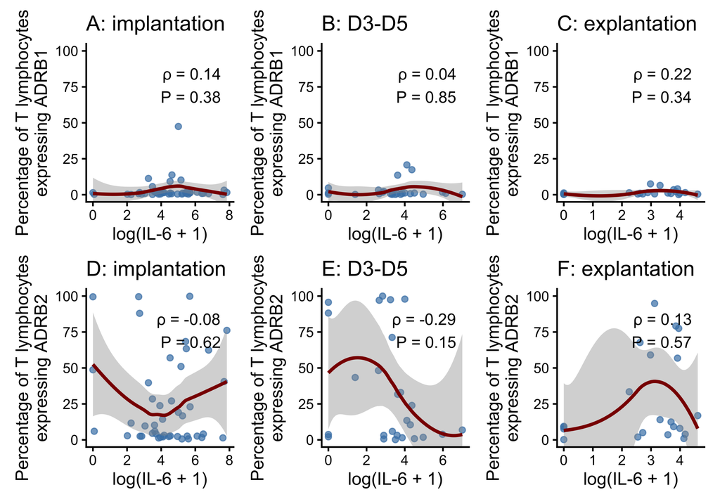

```r
Figure_1
```

```r
ggsave("FIGURES/Figure1.pdf",
       plot   = Figure_1,
       width  = 240, height = 160, units = "mm",
       device = cairo_pdf, bg = "white")
```